# PML project

Qingliang Li

5/22/2020

## Background

Using devices such as Jawbone Up, Nike FuelBand, and Fitbit it is now possible to collect a large amount of data about personal activity relatively inexpensively. One thing that people regularly do is quantify how much of a particular activity they do, but they rarely quantify how well they do it. In this project, my goal is to use data from accelerometers on the belt, forearm, arm, and dumbell of 6 participants. They were asked to perform barbell lifts correctly and incorrectly in 5 different ways.

## Data

The training data for this project are available here:

https://d396qusza40orc.cloudfront.net/predmachlearn/pml-training.csv

The test data are available here:

https://d396qusza40orc.cloudfront.net/predmachlearn/pml-testing.csv

The data for this project come from this source: http://web.archive.org/web/20161224072740/http:/groupware.les.inf.puc-rio.br/har. If you use the document you create for this class for any purpose please cite them as they have been very generous in allowing their data to be used for this kind of assignment.

## Projct task

The goal of the project is to predict the manner in which they did the exercise. This is the “classe” variable in the training set. I created a report describing how to built the model, how I used cross validation, what I think the expected out of sample error is, and why I made the choices I did. I will also use the prediction model to predict 20 different test cases.

### How I built the model

The outcome is the “classe” variable, a factor variable with 5 levels. *exactly according to the specification (Class A)* throwing the elbows to the front (Class B) *lifting the dumbbell only halfway (Class C)* lowering the dumbbell only halfway (Class D) *throwing the hips to the front (Class E) The model was built based on maximizing the accuracy and minimizing the out-of-sample error. Two models were tested using decision tree and random forest algorithms. The model with the highest accuracy was chosen to predict the test cases.

### How I used cross validation

I split the traning data, 70% was used to build the model, 30% was used to for testing.

### The expected out of sample error

The expected out-of-sample error is caculated by (1- accuracy), gained in the final model.

### Why I made the choices I did

## Load data

```r
dataTrain <- read.csv("pml-training.csv",
                      na.strings=c("NA","#DIV/0!", ""))
dataTest <- read.csv("pml-testing.csv",
                      na.strings=c("NA","#DIV/0!", ""))
str(dataTrain)
```

```
## 'data.frame':    19622 obs. of  160 variables:
##  $ X                       : int  1 2 3 4 5 6 7 8 9 10 ...
##  $ user_name               : Factor w/ 6 levels "adelmo","carlitos",..: 2 2 2 2 2 2 2 2 2 2 ...
##  $ raw_timestamp_part_1    : int  1323084231 1323084231 1323084231 1323084232 1323084232 1323084232 1323084232 1323084232 1323084232 1323084232 ...
##  $ raw_timestamp_part_2    : int  788290 808298 820366 120339 196328 304277 368296 440390 484323 484434 ...
##  $ cvtd_timestamp          : Factor w/ 20 levels "02/12/2011 13:32",..: 9 9 9 9 9 9 9 9 9 9 ...
##  $ new_window              : Factor w/ 2 levels "no","yes": 1 1 1 1 1 1 1 1 1 1 ...
##  $ num_window              : int  11 11 11 12 12 12 12 12 12 12 ...
##  $ roll_belt               : num  1.41 1.41 1.42 1.48 1.48 1.45 1.42 1.42 1.43 1.45 ...
##  $ pitch_belt              : num  8.07 8.07 8.07 8.05 8.07 8.06 8.09 8.13 8.16 8.17 ...
##  $ yaw_belt                : num  -94.4 -94.4 -94.4 -94.4 -94.4 -94.4 -94.4 -94.4 -94.4 -94.4 ...
##  $ total_accel_belt        : int  3 3 3 3 3 3 3 3 3 3 ...
##  $ kurtosis_roll_belt      : num  NA NA NA NA NA NA NA NA NA NA ...
##  $ kurtosis_picth_belt     : num  NA NA NA NA NA NA NA NA NA NA ...
##  $ kurtosis_yaw_belt       : logi  NA NA NA NA NA NA ...
```

[output cut: 86 more lines]

## Clean data, remove the columns which are all NA, delete irrelevant variables (columns 1 to 7)

```r
dataTrain <- dataTrain[,colSums(is.na(dataTrain)) == 0]
dataTest <- dataTest[,colSums(is.na(dataTest)) == 0]
dataTrain <- dataTrain[,-c(1:7)]
dataTest <- dataTest[,-c(1:7)]
```

## Split dataTrain, 70% for building model, 30% for testing

```r
library(caret)
```

```r
library(lattice)
library(rpart)
library(rpart.plot)
library(randomForest)
set.seed(052220)
train <- createDataPartition(y=dataTrain$classe,p=.70,list=F)
training <- dataTrain[train,]
testing <- dataTrain[-train,]
```

## Model 1: Decision Tree

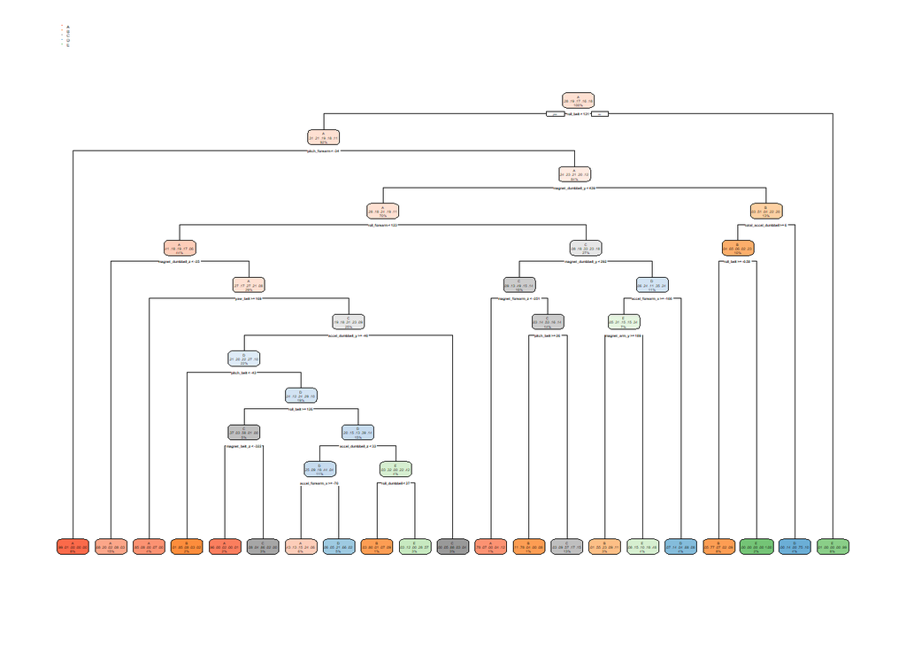

```r
model1 <- rpart(classe ~ ., data=training, method="class")

rpart.plot(model1)
```

## Test Model1 in testing

```r
pred1 <- predict(model1, testing, type = "class")
confusionMatrix(pred1, testing$classe)
```

```
## Confusion Matrix and Statistics
##
##           Reference
## Prediction    A    B    C    D    E
##          A 1534  265   70  166   53
##          B   48  632   82   46   65
##          C   39  101  775  157  142
##          D   31   88   71  504   46
##          E   22   53   28   91  776
##
## Overall Statistics
##
##                Accuracy : 0.7172
##                  95% CI : (0.7056, 0.7287)
##     No Information Rate : 0.2845
##     P-Value [Acc > NIR] : < 2.2e-16
##
##                   Kappa : 0.6391
##
##  Mcnemar's Test P-Value : < 2.2e-16
##
## Statistics by Class:
##
##                      Class: A Class: B Class: C Class: D Class: E
## Sensitivity            0.9164   0.5549   0.7554  0.52282   0.7172
## Specificity            0.8684   0.9492   0.9097  0.95204   0.9596
## Pos Pred Value         0.7347   0.7239   0.6384  0.68108   0.8000
## Neg Pred Value         0.9631   0.8988   0.9463  0.91059   0.9377
## Prevalence             0.2845   0.1935   0.1743  0.16381   0.1839
## Detection Rate         0.2607   0.1074   0.1317  0.08564   0.1319
## Detection Prevalence   0.3548   0.1483   0.2063  0.12574   0.1648
## Balanced Accuracy      0.8924   0.7520   0.8325  0.73743   0.8384
```

## Model 2: Random Forest

```r
model2 <- randomForest(classe ~. , data=training, method="class")

pred2 <- predict(model2, testing, type = "class")
confusionMatrix(pred2, testing$classe)
```

```
## Confusion Matrix and Statistics
##
##           Reference
## Prediction    A    B    C    D    E
##          A 1673   10    0    0    0
##          B    0 1128    5    0    0
##          C    1    1 1021   14    1
##          D    0    0    0  950    3
##          E    0    0    0    0 1078
##
## Overall Statistics
##
##                Accuracy : 0.9941
##                  95% CI : (0.9917, 0.9959)
##     No Information Rate : 0.2845
##     P-Value [Acc > NIR] : < 2.2e-16
##
##                   Kappa : 0.9925
##
##  Mcnemar's Test P-Value : NA
##
## Statistics by Class:
##
##                      Class: A Class: B Class: C Class: D Class: E
## Sensitivity            0.9994   0.9903   0.9951   0.9855   0.9963
## Specificity            0.9976   0.9989   0.9965   0.9994   1.0000
## Pos Pred Value         0.9941   0.9956   0.9836   0.9969   1.0000
## Neg Pred Value         0.9998   0.9977   0.9990   0.9972   0.9992
## Prevalence             0.2845   0.1935   0.1743   0.1638   0.1839
## Detection Rate         0.2843   0.1917   0.1735   0.1614   0.1832
## Detection Prevalence   0.2860   0.1925   0.1764   0.1619   0.1832
## Balanced Accuracy      0.9985   0.9946   0.9958   0.9924   0.9982
```

## Decision

Accuracy of Random Forest model (model2) was 0.994 (95% CI: (0.992, 0.996)), and accuracy of Decision Tree model (model1) was 0.717 (95% CI: (0.706, 0.729)). The random Forest model (model2) was choosen to predict the dataTest.

## Prediction

Using the random Forest model (model2) to predict the classe in dataTest

```r
prediction <- predict(model2, dataTest, type="class")
prediction
```

```
##  1  2  3  4  5  6  7  8  9 10 11 12 13 14 15 16 17 18 19 20
##  B  A  B  A  A  E  D  B  A  A  B  C  B  A  E  E  A  B  B  B
## Levels: A B C D E
```